# Exploring and Analysing BRFSS data

## Setup

```r
library(ggplot2)
library(dplyr)
```

### Load data

```r
load("brfss2013.RData")
```

## Part 1: Data

The Behavioral Risk Factor Surveillance System (BRFSS) is the nation’s premier system of health-related telephone surveys that collect state data about U.S. residents regarding their health-related risk behaviors, chronic health conditions, and use of preventive services. The interviewers collect data from randomly selected adult in a household in conducting BRFSS landline telephone survey and from an adult who participates by using a cellular telephone and resides in a private residence or college housing. BRFSS data was collectd through the random phone call surveys for non-institutionalized population., therefore the findings are generalized to US population that has either a landline telephone or cellular phone. This study is not generalized to those instituitionalized or those without telephones. Since all the data was collected (observed), this study is not based on any random experiment, hence there is no causal inference.

```r
str(brfss2013)
```

```
## 'data.frame':    491775 obs. of  330 variables:
##  $ X_state  : Factor w/ 55 levels "0","Alabama",..: 2 2 2 2 2 2 2 2 2 2 ...
##  $ fmonth   : Factor w/ 12 levels "January","February",..: 1 1 1 1 2 3 3 3 4 4 ...
##  $ idate    : int  1092013 1192013 1192013 1112013 2062013 3272013 3222013 3042013 4242013 4242013 ...
##  $ imonth   : Factor w/ 12 levels "January","February",..: 1 1 1 1 2 3 3 3 4 4 ...
##  $ iday     : Factor w/ 31 levels "1","2","3","4",..: 9 19 19 11 6 27 22 4 24 24 ...
##  $ iyear    : Factor w/ 2 levels "2013","2014": 1 1 1 1 1 1 1 1 1 1 ...
##  $ dispcode : Factor w/ 2 levels "Completed interview",..: 1 1 1 1 1 1 1 1 1 1 ...
##  $ seqno    : int  2013000580 2013000593 2013000600 2013000606 2013000608 2013000630 2013000634 2013000644 2013001305 2013001338 ...
##  $ X_psu    : int  2013000580 2013000593 2013000600 2013000606 2013000608 2013000630 2013000634 2013000644 2013001305 2013001338 ...
##  $ ctelenum : Factor w/ 1 level "Yes": 1 1 1 1 1 1 1 1 1 1 ...
##  $ pvtresd1 : Factor w/ 2 levels "Yes","No": 1 1 1 1 1 1 1 1 1 1 ...
##  $ colghous : Factor w/ 1 level "Yes": NA NA NA NA NA NA NA NA NA NA ...
##  $ stateres : Factor w/ 1 level "Yes": 1 1 1 1 1 1 1 1 1 1 ...
##  $ cellfon3 : Factor w/ 1 level "Not a cellular phone": 1 1 1 1 1 1 1 1 1 1 ...
```

[output cut: 86 more lines]

```r
dim(brfss2013)
```

```
## [1] 491775    330
```

```r
names(brfss2013)
```

```
##   [1] "X_state"   "fmonth"    "idate"     "imonth"    "iday"
##   [6] "iyear"     "dispcode"  "seqno"     "X_psu"     "ctelenum"
##  [11] "pvtresd1"  "colghous"  "stateres"  "cellfon3"  "ladult"
##  [16] "numadult"  "nummen"    "numwomen"  "genhlth"   "physhlth"
##  [21] "menthlth"  "poorhlth"  "hlthpln1"  "persdoc2"  "medcost"
##  [26] "checkup1"  "sleptim1"  "bphigh4"   "bpmeds"    "bloodcho"
##  [31] "cholchk"   "toldhi2"   "cvdinfr4"  "cvdcrhd4"  "cvdstrk3"
##  [36] "asthma3"   "asthnow"   "chcscncr"  "chcocncr"  "chccopd1"
##  [41] "havarth3"  "addepev2"  "chckidny"  "diabete3"  "veteran3"
##  [46] "marital"   "children"  "educa"     "employ1"   "income2"
##  [51] "weight2"   "height3"   "numhhol2"  "numphon2"  "cpdemo1"
##  [56] "cpdemo4"   "internet"  "renthom1"  "sex"       "pregnant"
##  [61] "qlactlm2"  "useequip"  "blind"     "decide"    "diffwalk"
##  [66] "diffdres"  "diffalon"  "smoke100"  "smokday2"  "stopsmk2"
##  [71] "lastsmk2"  "usenow3"   "alcday5"   "avedrnk2"  "drnk3ge5"
```

[output cut: 51 more lines]

## Part 2: Research questions

**Research quesion 1:** What is the relationship between education and income level?

**Research quesion 2:** What is the impact of number of hours slept on general health of males and females?

**Research quesion 3:** In year 2013, what percent of males and females got the flushots in the month of November?

## Part 3: Exploratory data analysis

**Research quesion 1:**

```r
study1<-brfss2013 %>%
  select(income2, educa)
```

```r
study1_NAremoved <- study1 %>%
  filter(!is.na(educa)) %>%
  filter(!is.na(income2))
```

```r
study1_NAremoved <- study1_NAremoved %>%
  mutate(College_graduate = ifelse(educa == "College 4 years or more (College graduate)", "Colledge graduate", "Not colledge graduate"))
```

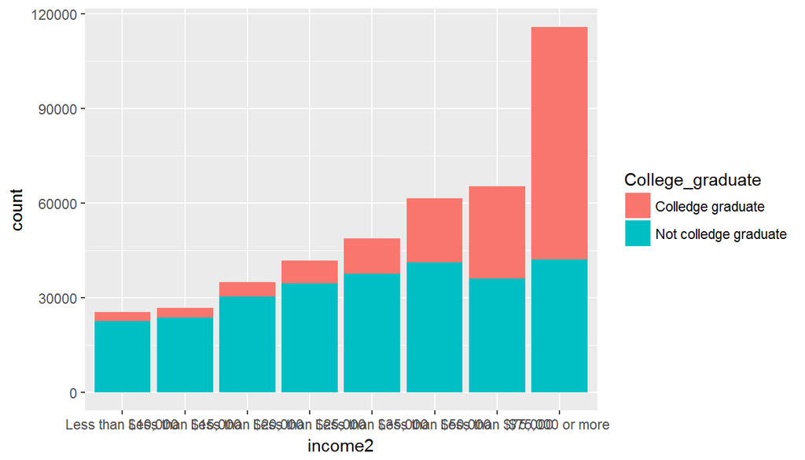

```r
ggplot(study1_NAremoved, aes(income2, fill = College_graduate))+geom_bar(position = "stack")
```

From above plot it can be configured that income is dependent on the level of education. Those who are College graduate they fall in the higher income range.

**Research quesion 2:**

```r
study2<-brfss2013 %>%
  select(sleptim1, physhlth, sex)
```

```r
study2_NAremoved <- study2 %>%
  filter(!is.na(sleptim1)) %>%
  filter(!is.na(physhlth)) %>%
   filter(!is.na(sex))
```

```r
study2_NAremoved <- study2_NAremoved %>%
  mutate(sleep_status = ifelse(sleptim1 >= 7 & sleptim1 <= 10, "optimum", "non optimum"))
```

```r
study2_NAremoved %>%
  group_by(sleep_status, sex) %>%  summarise(mean_physhlth = mean(physhlth), sd_physhlth = sd(physhlth), n = n())
```

```
## Source: local data frame [4 x 5]
## Groups: sleep_status [?]
##
##   sleep_status    sex mean_physhlth sd_physhlth      n
##          <chr> <fctr>         <dbl>       <dbl>  <int>
## 1  non optimum   Male      5.451177    9.978425  66659
## 2  non optimum Female      6.483813   10.371695  94427
## 3      optimum   Male      3.064919    7.552099 128714
## 4      optimum Female      3.615448    7.942115 184659
```

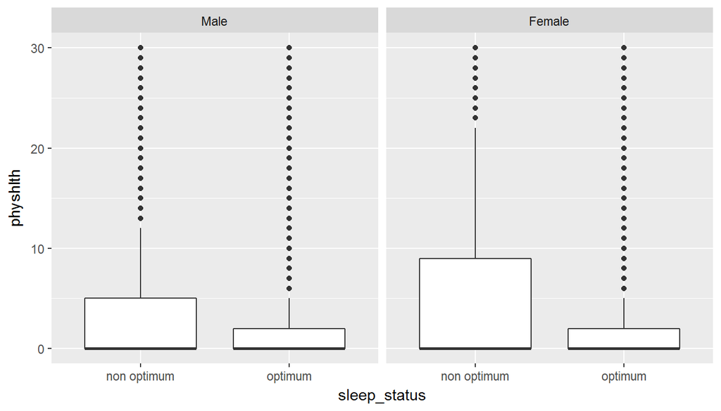

```r
ggplot(study2_NAremoved, aes(x = sleep_status, y = physhlth)) + geom_boxplot() + facet_wrap(~sex)
```

**Research quesion 3:**

```r
study3 <- brfss2013 %>%
  select(imonth, sex, flushot6)
```

```r
study3_NAremoved <- study3 %>%
  filter(!is.na(imonth)) %>%
  filter(!is.na(sex)) %>%
   filter(!is.na(flushot6))
```

```r
study3_November <- study3_NAremoved %>%
  filter(imonth == "November")
```

```r
study3_November %>%
    count(flushot6, sex)
```

```
## Source: local data frame [4 x 3]
## Groups: flushot6 [?]
##
##   flushot6    sex     n
##     <fctr> <fctr> <int>
## 1      Yes   Male  6554
## 2      Yes Female 10324
## 3       No   Male  9227
## 4       No Female 12009
```

```r
6554 / (6554 + 9227)
```

```
## [1] 0.4153095
```

Approx. 41% males got the flushots in November 2013.

```r
10324 / (10324 + 12009)
```

```
## [1] 0.4622756
```

Approx. 46% females got the flushots in November 2013.

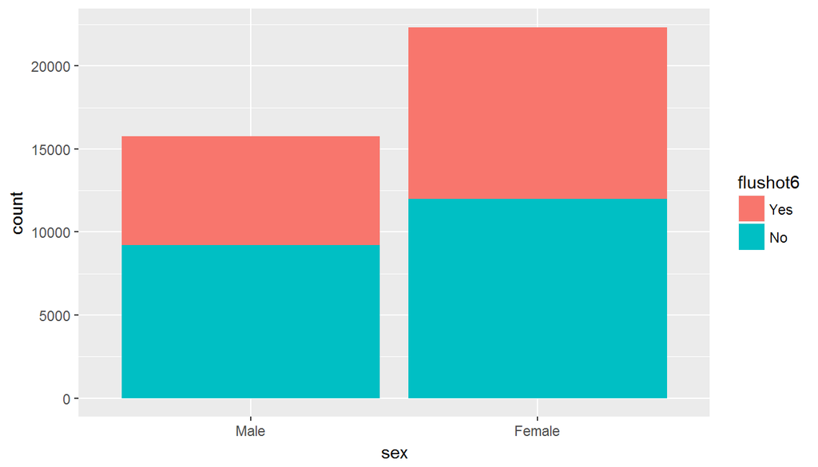

```r
ggplot(study3_November, aes(sex, fill = flushot6)) + geom_bar()
```

This plot and the calculation indicates that indicates that in November 2013, more females got the flushots that males.